# Puppy Raiser Questionnaire vs Outcome (Success, Fail)

Marinara Marcato

## Introduction

This document tests the hypothesis that there is a difference in behaviours reported in the standardised questionnaire Canine Behavioural Assessement & Research Questionnaire (C-BARQ) considering dog’s training outcome.

## Data Exploration

Importing data and converting to adequate datatypes

### Rows: Dogs

The number of dogs in the Puppy Raiser Questionnaire dataset. Selection criteria: dogs with a defined training outcome.

```
## Number of dogs: 63
```

```
## Training Outcome:
```

```
##
##    Fail Success
##      11      52
```

Analysing categorical demographic data: Sex, Breed. There was only one German Shepherd and Golden Doodle in the sample, their breeds were relabeled as “Other” for the data analysis.

```
##
##  F  M
## 30 33
```

```
## [1] "Original classes"
```

```
##
## GRxPoodle        GS        LR       LRx     LRxGR
##         1         1        25         9        27
```

```
## [1] "Processed classes"
```

```
##
## Other    LR LRxGR
##     2    25    36
```

Calculate and analyse age at assessment:

```
## Age at Assessment: Mean 16.13 Standard Deviation 3.4
```

### Columns: Features

Selecting features for predictive analysis. Below are the questionnaire items (variables) that were scored by the Puppy Raisers in a scale from ‘Never’, ‘Seldom’, ‘Sometimes’, ‘Usually’, ‘Always’.

```
## [1] "Items"
```

```
##   [1] "X1.When.off.the.leash.returns.immediately.when.called"
##   [2] "X2.Obeys.the.sit.command.immediately"
##   [3] "X3.Obeys.the.stay.command.immediately"
##   [4] "X4.Seems.to.attendlisten.closely.to.everything.you.say.or.do"
##   [5] "X5.Slow.to.respond.to.correction.or.punishment.thickskinned"
##   [6] "X6.Slow.to.learn.new.tricks.or.tasks"
##   [7] "X7.Easily.distracted.by.interesting.sights.sounds.or.smells"
##   [8] "X8.Will.fetch.or.attempt.to.fetch.sticks.balls.or.objects"
##   [9] "X9.When.verbally.corrected.or.punished.scolded.shouted.at.etc.by.you.or.a.household.member"
##  [10] "X10.When.approached.directly.by.an.unfamiliar.adult.while.being.walkedexercised.on.a.leash"
##  [11] "X11.When.approached.directly.by.an.unfamiliar.child.while.being.walkedexercised.on.a.leash"
##  [12] "X12.Toward.unfamiliar.persons.approaching.the.dog.while.she.is.in.your.car.at.the.gas.station.for.example"
##  [13] "X13.When.toys.bones.or.other.objects.are.taken.away.by.a.household.member"
##  [14] "X14.When.bathed.or.groomed.by.a.household.member"
##  [15] "X15.When.an.unfamiliar.person.approaches.you.or.another.member.of.your.family.at.home"
```

[output cut: 85 more lines]

```
## [1] "Factors, Demographic and outcome"
```

```
## 'data.frame':    63 obs. of  17 variables:
##  $ F_01.Stranger.directed.aggression: num  0.1 0 0.2 0 0 0 0 0.1 0.2 0 ...
##  $ F_02.Owner.directed.aggression   : num  0 0 0 0 0 0 0 0 0 0 ...
##  $ F_03.Dog.directed.aggression     : num  0 0 0 0 1 0 0 0 0 0 ...
##  $ F_04.Dog.directed.fear           : num  0.5 0 0.25 0.25 0 ...
##  $ F_05.Dog.rivalry                 : num  NA 0 0.25 0 NA 0 0 0 0.5 0 ...
##  $ F_06.Trainability                : num  3 3 3.12 3.62 2.62 ...
##  $ F_07.Chasing                     : num  1.25 0.667 1.75 2.25 1.333 ...
##  $ F_08.Stranger.directed.fear      : num  0 0 0.25 0 0 0 0 0 0 0 ...
##  $ F_09.Nonsocial.fear              : num  0 0 0.833 0.333 0 ...
##  $ F_10.Separation.related.problems : num  0.125 0.875 0.75 0 0.625 0 0 0.75 1 0.375 ...
##  $ F_11.Touch.sensitivity           : num  0.25 0 1.25 0 0 ...
##  $ F_12.Excitability                : num  2 0.6 2.167 0.833 0.833 ...
##  $ F_13.Attachment.attention.seeking: num  1.83 2 2.83 0.5 1.6 ...
##  $ F_14.Energy                      : num  3 2 2 0 1.5 0 2 4 1 1.5 ...
##  $ Sex                              : Factor w/ 2 levels "F","M": 1 2 2 2 2 2 2 1 2 1 ...
##  $ Breed                            : Factor w/ 3 levels "Other","LR","LRxGR": 3 3 2 3 3 3 3 3 3 3 ...
##  $ Outcome                          : Factor w/ 2 levels "Success","Fail": 1 1 1 1 1 1 1 2 1 1 ...
```

## Descriptive Statistics

Calculate and save the descritive statistics of the features selected for hypothesis testing the association with training outcome. Analysis missing data.

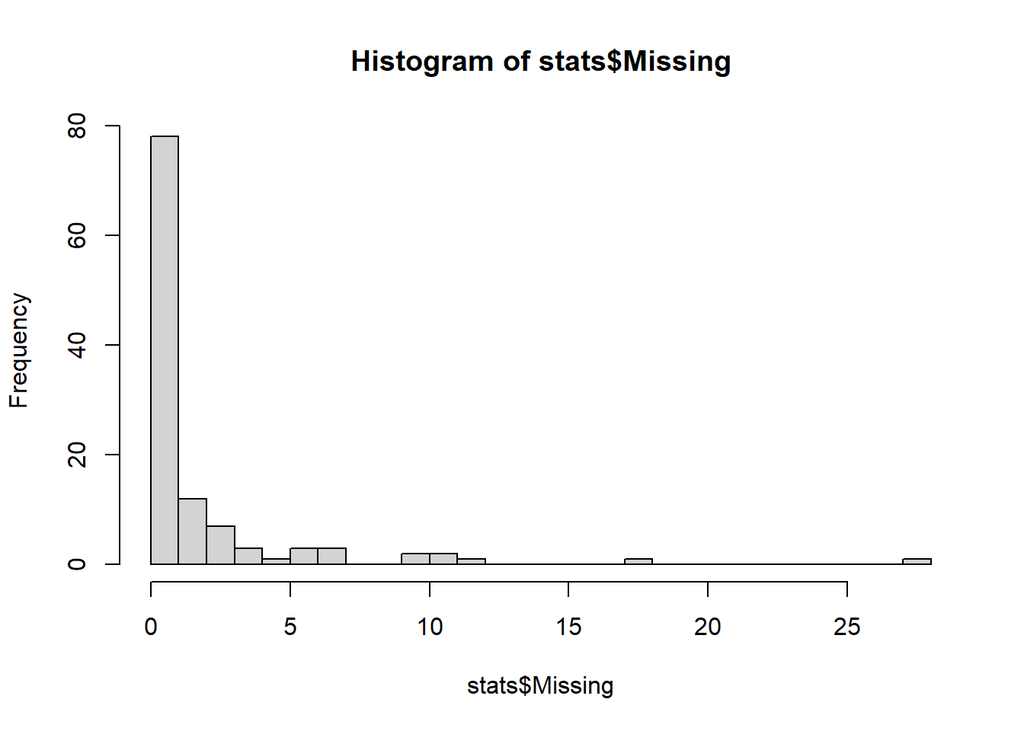

```
## [1] "Features sorted by number of missing rows"
```

```
##                                                                                                                                    Missing
## X49.When.having.nails.clipped.by.a.household.member                                                                                     28
## X76.Chases.or.would.chase.squirrels.rabbits.and.other.small.animals.given.the.opportunity                                               18
## X34.When.approached.while.eating.by.another.familiar.household.dog.NA.if.no.other.dogs                                                  12
## X33.When.approached.at.a.favorite.restingsleeping.place.by.another.familiar.household.dog.NA.if.no.other.dogs                           11
## F_05.Dog.rivalry                                                                                                                        11
## X32.Towards.another.familiar.dog.in.your.household.NA.if.no.other.dogs                                                                  10
## X35.When.approached.while.playing.withchewing.a.favorite.toy.bone.object.etc.by.another.familiar.household.dog.NA.if.no.other.dogs      10
## X74.Chases.or.would.chase.cats.given.the.opportunity                                                                                     7
## X93.Stares.intently.at.nothing.visible                                                                                                   7
## X100.Displays.other.bizarre.strange.or.repetitive.behaviors                                                                              7
## X5.Slow.to.respond.to.correction.or.punishment.thickskinned                                                                              6
## X9.When.verbally.corrected.or.punished.scolded.shouted.at.etc.by.you.or.a.household.member                                               6
## X77.Escapes.or.would.escape.from.home.or.yard.given.the.chance                                                                           6
## X96.Chasesfollows.shadows.light.spots.etc                                                                                                5
## X52.When.unfamiliar.dogs.visit.your.home                                                                                                 4
```

## Univariate Logistic Regression

Logistic Regression one-way analysis of variance test was used to investigate whether there was a statistically significant difference between the behaviours reported by Puppy Raisers and the Training Outcome of the dogs. C-BARQ Correlation with Training Outcome.

Breeds and Sex (p = 0.61361)were not significantly associated with training outcome.

```
## $Sex
##
## Call:
## glm(formula = Outcome ~ x, family = binomial(link = logit), data = data,
##     na.action = na.exclude)
##
## Deviance Residuals:
##     Min       1Q   Median       3Q      Max
## -0.6681  -0.6681  -0.5732  -0.5732   1.9427
##
## Coefficients:
##             Estimate Std. Error z value Pr(>|z|)
## (Intercept)  -1.3863     0.4564  -3.037  0.00239 **
## xM           -0.3365     0.6664  -0.505  0.61361
## ---
## Signif. codes:  0 '***' 0.001 '**' 0.01 '*' 0.05 '.' 0.1 ' ' 1
##
## (Dispersion parameter for binomial family taken to be 1)
##
##     Null deviance: 58.352  on 62  degrees of freedom
## Residual deviance: 58.096  on 61  degrees of freedom
## AIC: 62.096
##
## Number of Fisher Scoring iterations: 4
```

```
## [1] LRxGR LR    Other
## Levels: Other LR LRxGR
```

```
## Difference between Other and LR:      0.4390785   -> not significant
```

```
## Difference between Other and LRxGR:   0.1685832   -> not significant
```

```
## [1] "Columns 9,10,13,17,30,37 are CONSTANT, that's why they p_values don't make sense"
```

```
## [1] -4.443853 -4.680547 -4.680547 -4.680547 -4.680547 -4.614145
```

Analysing p-values.

```
## [1] "Number of features considering each level of significance using Logistic Regression p-value test"
```

```
## significant_0.05  significant_0.1  significant_0.2
##               29               43               56
```

Analysing deviance.

```
## Number of features whose univariate models resulted in a significant difference in deviance:  65
```

```
## Full Feature Set with p<0.05  63 30
```

```
##  [1] "X1.When.off.the.leash.returns.immediately.when.called"
##  [2] "X26.Toward.unfamiliar.dogs.visiting.your.home"
##  [3] "X27.Toward.cats.squirrels.or.other.small.animals.entering.your.yard"
##  [4] "X29.When.barked.growled.or.lunged.at.by.another.unfamiliar.dog"
##  [5] "X38.In.response.to.sudden.or.loud.noises.eg.vacuum.cleaner.car.backfire.road.drills.objects.being.dropped.etc"
##  [6] "X45.When.approached.directly.by.an.unfamiliar.dog.of.the.same.or.larger.size"
##  [7] "X53.When.barked.growled.or.lunged.at.by.an.unfamiliar.dog"
##  [8] "X54.Shaking.shivering.or.trembling"
##  [9] "X56.Restlessnessagitationpacing"
## [10] "X57.Whining"
## [11] "X61.Barking"
## [12] "X62.When.you.or.other.members.of.the.household.come.home.after.a.brief.absence"
## [13] "X63.When.playing.with.you.or.other.members.of.your.household"
## [14] "X64.When.doorbell.rings"
## [15] "X65.Just.before.being.taken.for.a.walk"
## [16] "X66.Just.before.being.taken.on.a.car.trip"
## [17] "X75.Chases.or.would.chase.birds.given.the.opportunity"
## [18] "X77.Escapes.or.would.escape.from.home.or.yard.given.the.chance"
## [19] "X82.Begs.persistently.for.food.when.people.are.eating"
## [20] "X85.Pulls.excessively.hard.when.on.the.leash"
## [21] "X90.Hyperactive.restless.has.trouble.settling.down"
## [22] "X93.Stares.intently.at.nothing.visible"
## [23] "X99.Licks.people.or.objects.excessively"
## [24] "F_01.Stranger.directed.aggression"
## [25] "F_03.Dog.directed.aggression"
## [26] "F_04.Dog.directed.fear"
## [27] "F_09.Nonsocial.fear"
## [28] "F_10.Separation.related.problems"
## [29] "F_12.Excitability"
## [30] "Outcome"
```

```
## Reduced Feature Set with p<0.05   63 13
```

```
##  [1] "X77.Escapes.or.would.escape.from.home.or.yard.given.the.chance"
##  [2] "X82.Begs.persistently.for.food.when.people.are.eating"
##  [3] "X85.Pulls.excessively.hard.when.on.the.leash"
##  [4] "X90.Hyperactive.restless.has.trouble.settling.down"
##  [5] "X93.Stares.intently.at.nothing.visible"
##  [6] "X99.Licks.people.or.objects.excessively"
##  [7] "F_01.Stranger.directed.aggression"
##  [8] "F_03.Dog.directed.aggression"
##  [9] "F_04.Dog.directed.fear"
## [10] "F_09.Nonsocial.fear"
## [11] "F_10.Separation.related.problems"
## [12] "F_12.Excitability"
## [13] "Outcome"
```

## Multivariate Logistic Regression Model: Multicollinearity

Calculate Variance Inflation Factor (VIF) to avoid multicollinearity. The glm models were built on the Full and Reduced Feature Sets with p < 0.05 and excude any sample containing NAs. VIF larger than 5 or 10 is large and indicate a high level of multicollinearity.

The resulting multivariate logistic regression models are NOT looking good, p_values are all roughly 1. VIF values indicate a high degree of multicollinearity. They were much larger for the full model compared to the reduced model.

```
## [1] "VIF full"
```

```
##                                                         X1.When.off.the.leash.returns.immediately.when.called
##                                                                                                      89.83031
##                                                                 X26.Toward.unfamiliar.dogs.visiting.your.home
##                                                                                                      83.03971
##                                           X27.Toward.cats.squirrels.or.other.small.animals.entering.your.yard
##                                                                                                       6.57450
##                                                X29.When.barked.growled.or.lunged.at.by.another.unfamiliar.dog
##                                                                                                     165.62972
## X38.In.response.to.sudden.or.loud.noises.eg.vacuum.cleaner.car.backfire.road.drills.objects.being.dropped.etc
##                                                                                                      32.06300
##                                  X45.When.approached.directly.by.an.unfamiliar.dog.of.the.same.or.larger.size
##                                                                                                      62.18022
##                                                     X53.When.barked.growled.or.lunged.at.by.an.unfamiliar.dog
##                                                                                                     564.05528
##                                                                            X54.Shaking.shivering.or.trembling
##                                                                                                      23.33323
##                                                                               X56.Restlessnessagitationpacing
##                                                                                                     256.68583
##                                                                                                   X57.Whining
##                                                                                                     243.21271
##                                                                                                   X61.Barking
##                                                                                                      50.86437
##                                X62.When.you.or.other.members.of.the.household.come.home.after.a.brief.absence
##                                                                                                     132.99083
##                                                  X63.When.playing.with.you.or.other.members.of.your.household
##                                                                                                     143.55557
##                                                                                       X64.When.doorbell.rings
##                                                                                                     105.06409
##                                                                        X65.Just.before.being.taken.for.a.walk
##                                                                                                      51.90892
##                                                                     X66.Just.before.being.taken.on.a.car.trip
##                                                                                                     173.98659
##                                                         X75.Chases.or.would.chase.birds.given.the.opportunity
##                                                                                                      10.55917
##                                                X77.Escapes.or.would.escape.from.home.or.yard.given.the.chance
##                                                                                                     102.40529
##                                                         X82.Begs.persistently.for.food.when.people.are.eating
##                                                                                                      76.97818
```

[output cut: 20 more lines]

```
## VIF reduced
```

```
## X77.Escapes.or.would.escape.from.home.or.yard.given.the.chance
##                                                       7.314572
##          X82.Begs.persistently.for.food.when.people.are.eating
##                                                     100.351249
##                   X85.Pulls.excessively.hard.when.on.the.leash
##                                                      24.782805
##             X90.Hyperactive.restless.has.trouble.settling.down
##                                                      40.037691
##                         X93.Stares.intently.at.nothing.visible
##                                                      33.939314
##                        X99.Licks.people.or.objects.excessively
##                                                      33.357232
##                              F_01.Stranger.directed.aggression
##                                                       2.828702
##                                   F_03.Dog.directed.aggression
##                                                      63.561422
##                                         F_04.Dog.directed.fear
##                                                     109.237670
##                                            F_09.Nonsocial.fear
##                                                      19.032802
##                               F_10.Separation.related.problems
##                                                       9.121504
##                                              F_12.Excitability
##                                                       8.922140
```

## Multivariate Logistic Regression Model: Preprocessing with KNN Imputation and PCA + Feature Selection with RFE

Features selection was performed using the Caret package Recursive Feature Elimination rfe function. Logistic Regression was used to model the dataset and Leave One Subject Out Cross Validation was employed to validate the results. [Caret RFE](https://search.r-project.org/CRAN/refmans/caret/html/rfe.html), [Caret RFE Control](https://search.r-project.org/CRAN/refmans/caret/html/rfeControl.html), [Examples using RFE with Recipes](http://topepo.github.io/caret/recursive-feature-elimination.html#rferecipes) [Example RFE + RF as predictor](https://towardsdatascience.com/effective-feature-selection-recursive-feature-elimination-using-r-148ff998e4f7), [RFE + ROC as metric](https://stackoverflow.com/questions/18242692/r-package-caret-rfe-function-how-to-customize-metric-to-use-auc).

I did not manage to make the preprocessing work within rfe using LOOCV, it only works with repeatedCV. Therefore, there is some dataleakage in the ROC estimations. However, the resulting models also had PC01 and sometimes PC05, depending on the number of repeats with ROC varying between 0.80 and 0.87.

Both Full and Reduced datasets were used for this analysis.

- Full -> ROC: 0.81, TPR: 0.92, TNR: 0.36, AIC: 45.038
- Reduced -> ROC: 0.75, TPR: 0.98, TNR: 0.36, AIC: 44.661

Interpreting performance metrics:

- Sensitivity - positive results for fail dogs. How many withdrawn dogs were flaged as fail?
- Type 1 error = false positive rate: 1-TPR = 8% of the dogs flagged as fail would successed.
- Specificity - negative result for success dogs. How many graduate dogs were flaged as success?
- Type 2 error = false negative error: 1-TNR = 64% of the dogs flagged as success would fail.

The results reveals that the model learnt on the full dataset delivers a better AUC-ROC 0.81 compared to 0.7483. On the other hand, the TPR or Sensitivity is 98% for the Reduced model and 92% for the Reduced model. Therefore, the Reduced model might be a better choice. However, it is important to highlight that the sample size is rather smal. Such difference in performance may be caused for just a few dogs being correctly classified.

```
## [1] "p<0.05 + full"
```

```
## [1] "Dimensions of original dataset:"
## [1] 63 30
```

```
##
## Recursive feature selection
##
## Outer resampling method: Leave-One-Out Cross-Validation
##
## Resampling performance over subset size:
##
##  Variables    ROC   Sens   Spec Selected
##          1 0.7010 0.9808 0.2727
##          2 0.8129 0.9231 0.3636        *
##          3 0.5892 0.9423 0.2727
##          4 0.5577 0.9038 0.2727
##          5 0.4895 0.8846 0.2727
##          6 0.4580 0.9038 0.3636
##          7 0.4545 0.9038 0.3636
##          8 0.4458 0.8654 0.3636
##          9 0.4668 0.8077 0.3636
##         10 0.4510 0.8077 0.3636
##         11 0.4213 0.8077 0.3636
##         12 0.4126 0.8846 0.3636
##         13 0.4073 0.8269 0.3636
##         14 0.4003 0.8269 0.3636
##         15 0.4003 0.8269 0.3636
##         16 0.3951 0.8269 0.2727
##         17 0.3916 0.8269 0.2727
##
## The top 2 variables (out of 2):
##    PC01, PC05
##
##
## Call:
## glm(formula = Class ~ ., family = "binomial", data = tmp)
##
## Deviance Residuals:
##     Min       1Q   Median       3Q      Max
## -1.3665  -0.4831  -0.3127  -0.2264   2.3685
##
## Coefficients:
##             Estimate Std. Error z value Pr(>|z|)
## (Intercept)  -2.0199     0.4660  -4.335 1.46e-05 ***
## PC01         -0.4834     0.1568  -3.082  0.00206 **
## PC05         -0.5013     0.3206  -1.564  0.11786
## ---
## Signif. codes:  0 '***' 0.001 '**' 0.01 '*' 0.05 '.' 0.1 ' ' 1
##
## (Dispersion parameter for binomial family taken to be 1)
##
##     Null deviance: 58.352  on 62  degrees of freedom
## Residual deviance: 39.038  on 60  degrees of freedom
## AIC: 45.038
##
## Number of Fisher Scoring iterations: 5
```

```
##
## deviance difference:  19.31428
## df difference:  2
## level of significance:  6.396716e-05
## the model is a good fit:  TRUE
```

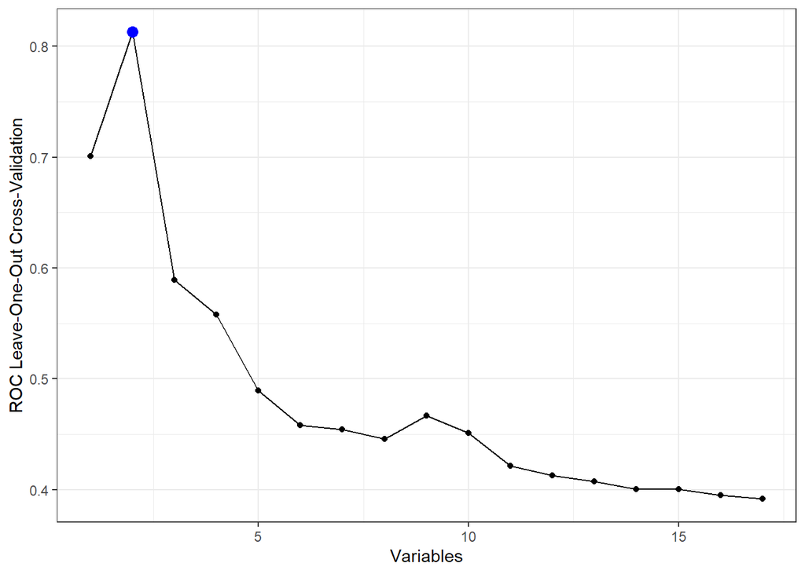

```
## [1] "p<0.05 + reduced"
```

```
## [1] "Dimensions of original dataset:"
## [1] 63 13
```

```
##
## Recursive feature selection
##
## Outer resampling method: Leave-One-Out Cross-Validation
##
## Resampling performance over subset size:
##
##  Variables    ROC   Sens   Spec Selected
##          1 0.7483 0.9808 0.3636        *
##          2 0.6678 0.9615 0.3636
##          3 0.6381 0.9423 0.3636
##          4 0.5997 0.9038 0.2727
##          5 0.5629 0.9038 0.1818
##          6 0.5157 0.8654 0.1818
##          7 0.4948 0.8654 0.2727
##          8 0.4633 0.8846 0.2727
##          9 0.4528 0.8654 0.2727
##         10 0.4563 0.8654 0.2727
##
## The top 1 variables (out of 1):
##    PC01
##
##
## Call:
## glm(formula = Class ~ ., family = "binomial", data = tmp)
##
## Deviance Residuals:
##     Min       1Q   Median       3Q      Max
## -1.3429  -0.4360  -0.3750  -0.2857   2.3377
##
## Coefficients:
##             Estimate Std. Error z value Pr(>|z|)
## (Intercept)  -1.9391     0.4337  -4.471 7.79e-06 ***
## PC01          0.6857     0.2192   3.128  0.00176 **
## ---
## Signif. codes:  0 '***' 0.001 '**' 0.01 '*' 0.05 '.' 0.1 ' ' 1
##
## (Dispersion parameter for binomial family taken to be 1)
##
##     Null deviance: 58.352  on 62  degrees of freedom
## Residual deviance: 40.661  on 61  degrees of freedom
## AIC: 44.661
##
## Number of Fisher Scoring iterations: 5
```

```
##
## deviance difference:  17.69131
## df difference:  1
## level of significance:  2.598113e-05
## the model is a good fit:  TRUE
```

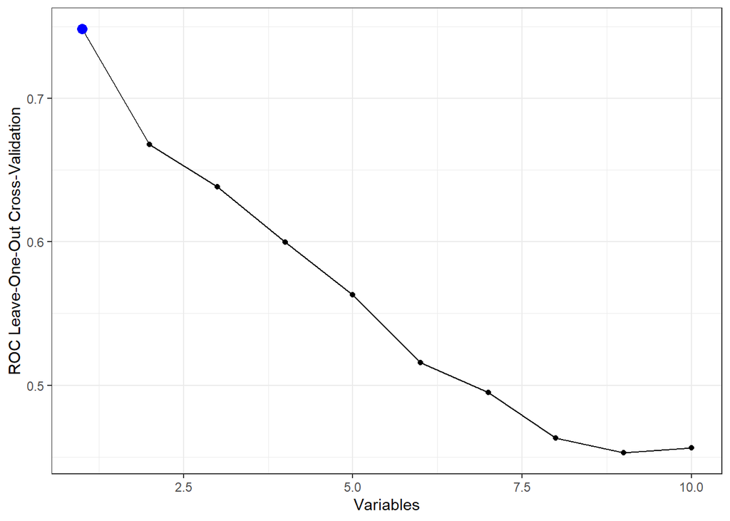

## Multivariate Logistic Regression Model: Output Analysis

```
##                 OR  2.5 % 97.5 %
## (Intercept) 0.1327 0.0458 0.2988
## PC01        0.6167 0.4223 0.7976
## PC05        0.6057 0.3100 1.1220
```

```
##                 OR  2.5 % 97.5 %
## (Intercept) 0.1438 0.0548 0.3102
## PC01        1.9852 1.3866 3.3444
```

## Feature Importance

Analysis of the principal component loadings that were used in the best Multivariate Logistic Regression Model.

### Full Feature Set

The 5 highest values in PC1 are “X26 Toward unfamiliar dogs visiting your home”, “X45 When approached directly by an unfamiliar dog of the same or larger size”, “X29 When barked growled or lunged at by another unfamiliar dog”, “F_03 Dog directed aggression”, “F_04 Dog directed fear” which indicate that this principal component places most variation in these variables related to fearful and agressive behaviour.

```
## [1] "PC1 and PC2 values"
```

```
##                                                                                                            terms
## 1                                                                                         F_04.Dog.directed.fear
## 2                                                                                   F_03.Dog.directed.aggression
## 3                                                 X29.When.barked.growled.or.lunged.at.by.another.unfamiliar.dog
## 4                                   X45.When.approached.directly.by.an.unfamiliar.dog.of.the.same.or.larger.size
## 5                                                                  X26.Toward.unfamiliar.dogs.visiting.your.home
## 6                                                                                              F_12.Excitability
## 7                                                                         X93.Stares.intently.at.nothing.visible
## 8                                                                         X65.Just.before.being.taken.for.a.walk
## 9                                                      X53.When.barked.growled.or.lunged.at.by.an.unfamiliar.dog
## 10                                                  X63.When.playing.with.you.or.other.members.of.your.household
## 11                                                                              F_10.Separation.related.problems
## 12                                                                     X66.Just.before.being.taken.on.a.car.trip
## 13                                                                                           F_09.Nonsocial.fear
## 14                                X62.When.you.or.other.members.of.the.household.come.home.after.a.brief.absence
```

[output cut: 45 more lines]

```
##                                                                                                            terms
## 1                                                          X75.Chases.or.would.chase.birds.given.the.opportunity
## 2                                                                         X65.Just.before.being.taken.for.a.walk
## 3                                                                      X66.Just.before.being.taken.on.a.car.trip
## 4                                                                             X54.Shaking.shivering.or.trembling
## 5                                                          X1.When.off.the.leash.returns.immediately.when.called
## 6                                                 X77.Escapes.or.would.escape.from.home.or.yard.given.the.chance
## 7                                                                        X99.Licks.people.or.objects.excessively
## 8                                                          X82.Begs.persistently.for.food.when.people.are.eating
## 9                                                                                            F_09.Nonsocial.fear
## 10                                           X27.Toward.cats.squirrels.or.other.small.animals.entering.your.yard
## 11                                                                               X56.Restlessnessagitationpacing
## 12                                                                  X85.Pulls.excessively.hard.when.on.the.leash
## 13                                                                             F_01.Stranger.directed.aggression
## 14                                                                 X26.Toward.unfamiliar.dogs.visiting.your.home
```

[output cut: 45 more lines]

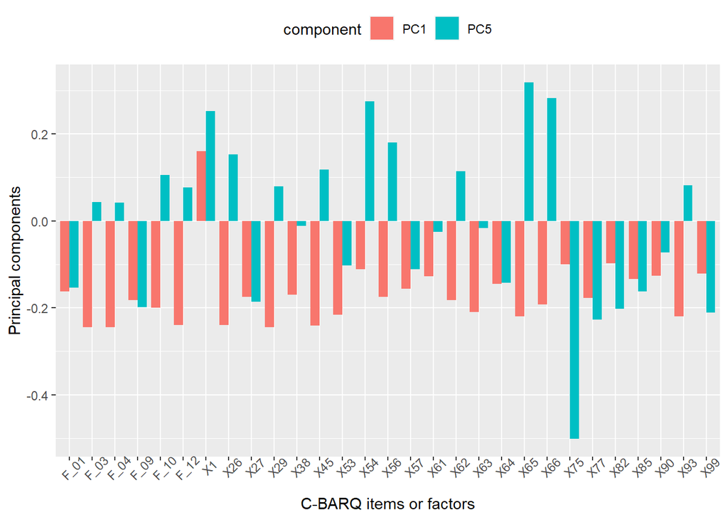

```
##  [1] "X1.When.off.the.leash.returns.immediately.when.called"
##  [2] "X26.Toward.unfamiliar.dogs.visiting.your.home"
##  [3] "X27.Toward.cats.squirrels.or.other.small.animals.entering.your.yard"
##  [4] "X29.When.barked.growled.or.lunged.at.by.another.unfamiliar.dog"
##  [5] "X38.In.response.to.sudden.or.loud.noises.eg.vacuum.cleaner.car.backfire.road.drills.objects.being.dropped.etc"
##  [6] "X45.When.approached.directly.by.an.unfamiliar.dog.of.the.same.or.larger.size"
##  [7] "X53.When.barked.growled.or.lunged.at.by.an.unfamiliar.dog"
##  [8] "X54.Shaking.shivering.or.trembling"
##  [9] "X56.Restlessnessagitationpacing"
## [10] "X57.Whining"
## [11] "X61.Barking"
## [12] "X62.When.you.or.other.members.of.the.household.come.home.after.a.brief.absence"
## [13] "X63.When.playing.with.you.or.other.members.of.your.household"
## [14] "X64.When.doorbell.rings"
## [15] "X65.Just.before.being.taken.for.a.walk"
## [16] "X66.Just.before.being.taken.on.a.car.trip"
## [17] "X75.Chases.or.would.chase.birds.given.the.opportunity"
## [18] "X77.Escapes.or.would.escape.from.home.or.yard.given.the.chance"
## [19] "X82.Begs.persistently.for.food.when.people.are.eating"
## [20] "X85.Pulls.excessively.hard.when.on.the.leash"
## [21] "X90.Hyperactive.restless.has.trouble.settling.down"
## [22] "X93.Stares.intently.at.nothing.visible"
## [23] "X99.Licks.people.or.objects.excessively"
## [24] "F_01.Stranger.directed.aggression"
## [25] "F_03.Dog.directed.aggression"
## [26] "F_04.Dog.directed.fear"
## [27] "F_09.Nonsocial.fear"
## [28] "F_10.Separation.related.problems"
## [29] "F_12.Excitability"
```

### Reduced Feature Set

```
##                                                             terms     value
## 1                                               F_12.Excitability 0.3454253
## 2                                    F_03.Dog.directed.aggression 0.3370007
## 3                          X93.Stares.intently.at.nothing.visible 0.3350710
## 4                                          F_04.Dog.directed.fear 0.3331709
## 5                                F_10.Separation.related.problems 0.3191851
## 6  X77.Escapes.or.would.escape.from.home.or.yard.given.the.chance 0.2829597
## 7                               F_01.Stranger.directed.aggression 0.2824399
## 8                                             F_09.Nonsocial.fear 0.2688120
## 9              X90.Hyperactive.restless.has.trouble.settling.down 0.2458539
## 10                   X85.Pulls.excessively.hard.when.on.the.leash 0.2388447
## 11          X82.Begs.persistently.for.food.when.people.are.eating 0.2246968
## 12                        X99.Licks.people.or.objects.excessively 0.2046445
```

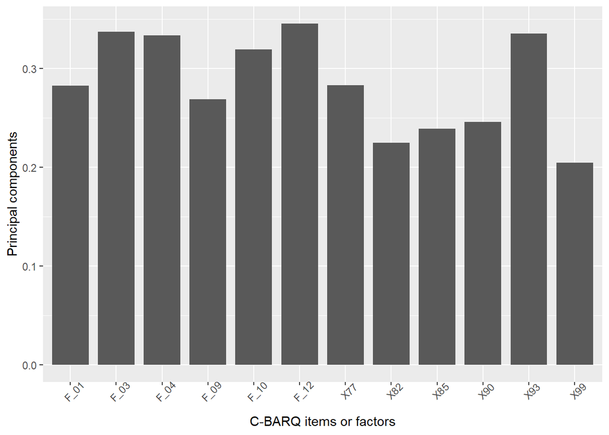

```
##  [1] "X77.Escapes.or.would.escape.from.home.or.yard.given.the.chance"
##  [2] "X82.Begs.persistently.for.food.when.people.are.eating"
##  [3] "X85.Pulls.excessively.hard.when.on.the.leash"
##  [4] "X90.Hyperactive.restless.has.trouble.settling.down"
##  [5] "X93.Stares.intently.at.nothing.visible"
##  [6] "X99.Licks.people.or.objects.excessively"
##  [7] "F_01.Stranger.directed.aggression"
##  [8] "F_03.Dog.directed.aggression"
##  [9] "F_04.Dog.directed.fear"
## [10] "F_09.Nonsocial.fear"
## [11] "F_10.Separation.related.problems"
## [12] "F_12.Excitability"
```

## Conclusion

This model could be used to flag dogs likely to be withdrawn from training for behavioural reasons. Dog trainers could consider the output to re-assess and adjust the training programme for flagged dogs in order to address behavioural issues. Considering the higher TPR achieved by the Reduced model, that might be a better choice when employing this system to correcly identify unsuitable dogs for the training programme.